# Ford GoBike Data Analysis

## by Michael Maher

## Investigation Overview

> Analyzing common trends and user behavior with clearity to help decision takers take the right decision

## Dataset Overview

> This data set includes information about individual rides made in a bike-sharing system covering the greater San Francisco Bay area. This is just a sample of the data based on time between 2019-02-01 and 2019-02-28

> **it includes those features:** "duration_sec" "start_time" "end_time" "start_station_id" "start_station_name" "start_station_latitude" "start_station_longitude" "end_station_id" "end_station_name" "end_station_latitude" "end_station_longitude" "bike_id" "user_type" "member_birth_year" "member_gender" "bike_share_for_all_trip"

## (Visualization 1)

### **General stats:**

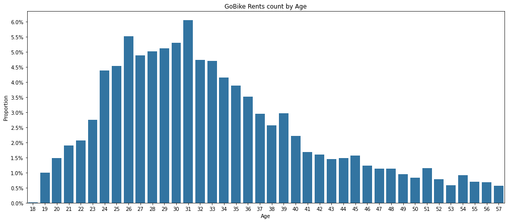

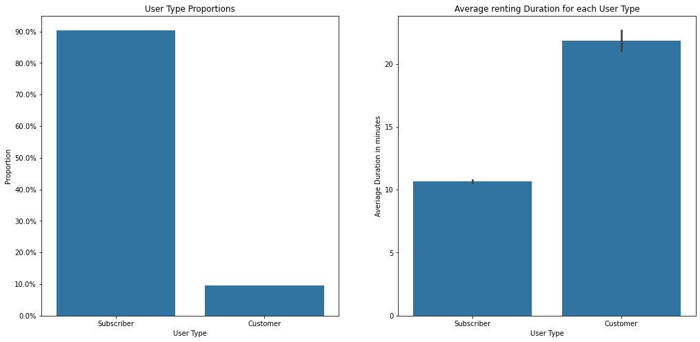

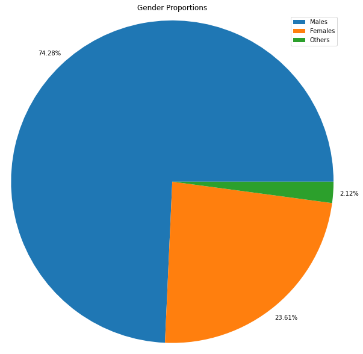

## (Visualization 2)

### Most Subscribers rent bikes for work, during working days, at 8am & 5pm.

### While most Customers rent bikes through out the week and for much longer duration, specially during weekends, Which makes it safe to assume that Customers rent for entertainment purposes.

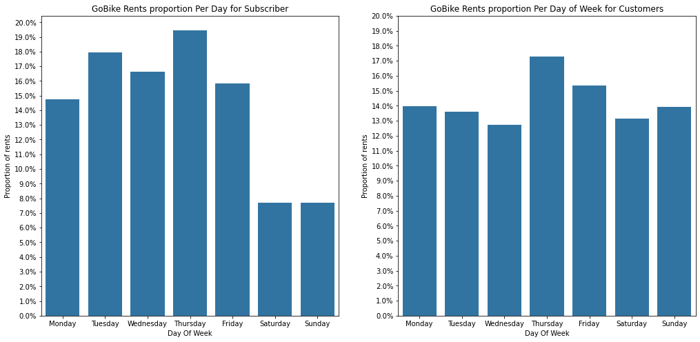

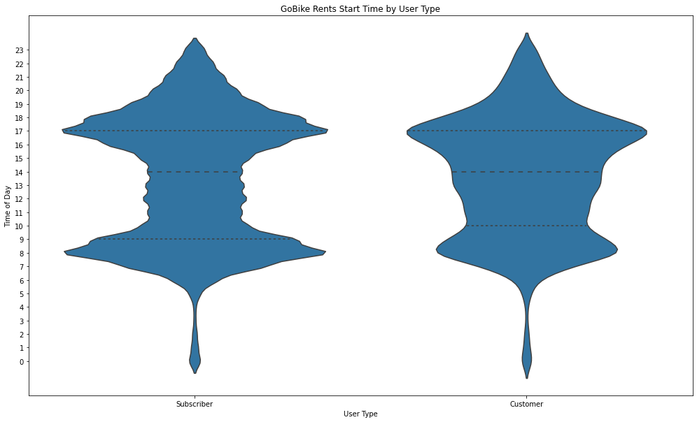

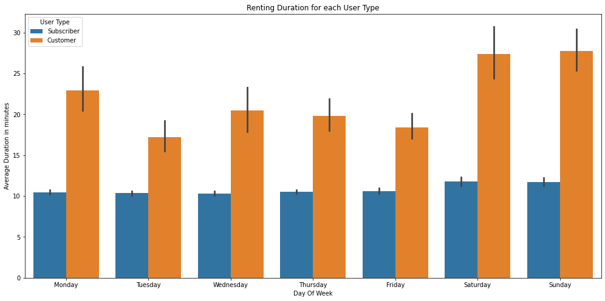

#### Note: While most subscribers don't rent during weekends, those who do tend to rent for a little longer duration as shown in the previous graph

## (Visualization 3)

### Genders doesn't have any effect on renting timing but it does have an effect on the renting duration

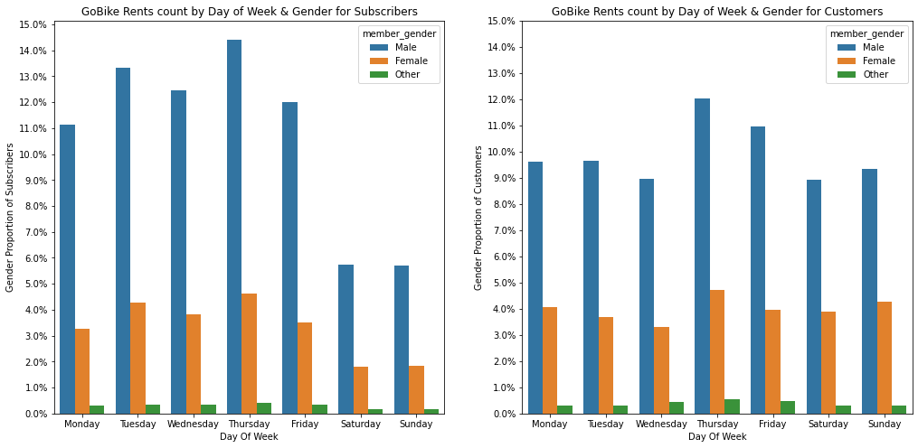

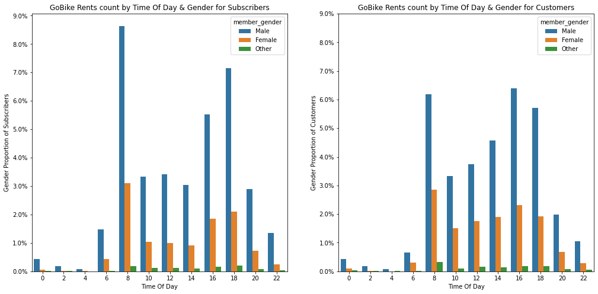

### Everything seems normal so far, now lets see the effect gender have on renting duration

### Over all males tend to rent for shorter duration.

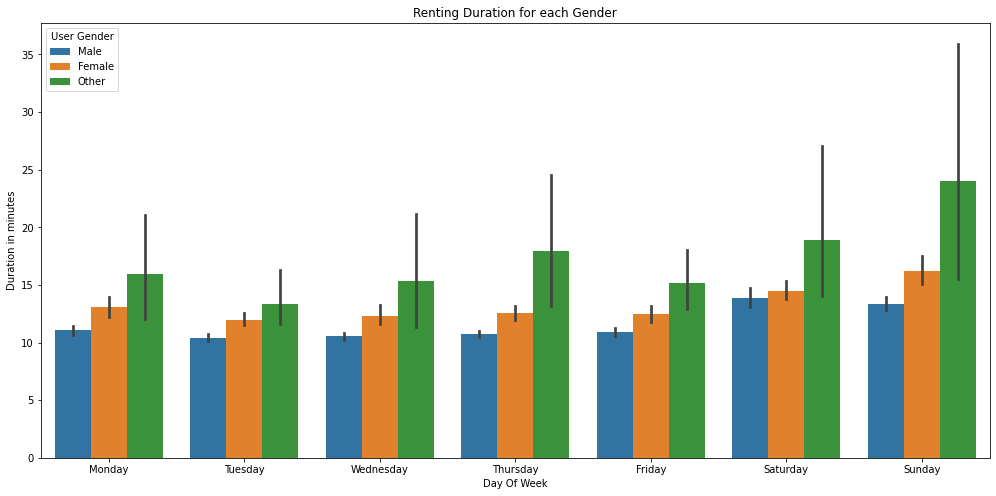

### But this is not always true when splitting the data according to User Type, since sometimes male "Customers" rent for longer duration than other genders.

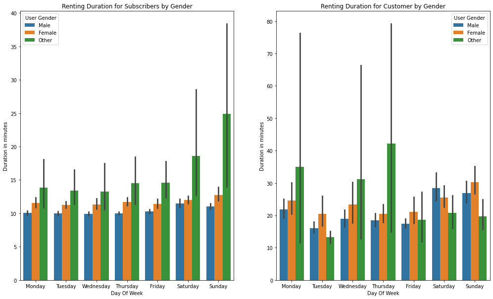

## (Visualization 4)

### Age doesn't seem to have big effect on renting duration less than 3 hours, and since most rides average between 10 to 20 minutes, this info is not very useful.

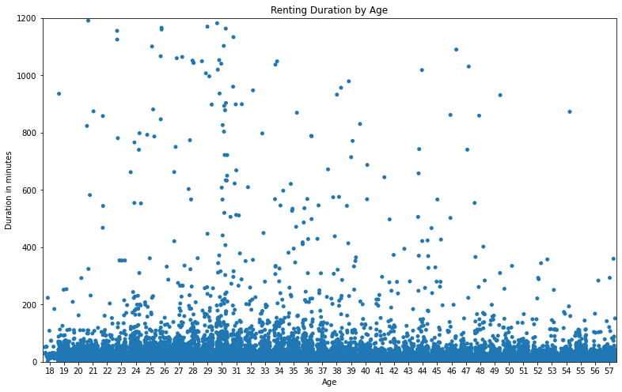